# TIMSS 2015 8th Grade

□ بررسی عوامل موثر بر عملکرد دانش آموزان :

در این بخش به بررسی عوامل موثر در عملکرد دانش آموزان پرداخته ایم. هر یک از این عوامل کلی را با دسته بندی به عامل هایی کوچک تر بررسی کرده ایم.  
برای نشان دادن تاثیر این عوامل از آزمون فرض Anova و در بعضی موارد Chi-Squared استفاده کرده ایم. همینطور برای هر یک ، دو نمودار نیز رسم شده است. این اطلاعات بر حسب جواب مدیر ، معلم ها ، والدین و خود دانش آموزان به پرسشنامه های آزمون بدست آمده است.

### Timss 8th Grade

#### Home Environment Support

در این قسمت، میانگین امتیاز دانش آموزان را برحسب وضعیت محیط خانه با هم مقایسه کرده ایم. برای تعیین وضعیت محیط خانه، عوامل مختلفی مانند

- منابع فیزیکی مانند اتاق مجزا، میز مطالعه، اینترنت و …
- میزان تحصیلات پدر و مادر
- صحبت کردن به زبان امتحان

> منابع فیزیکی:

در این قسمت دانش آموزان را بر حسب دسترسی به میز مطالعه، اتاق مجزا، کامپیوتر و … به دسته های مختلفی تقسیم کرده ایم.

```
##                        Df    Sum Sq   Mean Sq F value Pr(>F)
## as.factor(res.cat)      2 4.972e+08 248600466   29428 <2e-16 ***
## Residuals          268380 2.267e+09      8448
## ---
## Signif. codes:  0 '***' 0.001 '**' 0.01 '*' 0.05 '.' 0.1 ' ' 1
```

```
##
##  Pearson's Chi-squared test with simulated p-value (based on 2000
##  replicates)
##
## data:  matrix(as.numeric(home15.stat8th.summery$freq), nrow = 3, ncol = 3,     byrow = T)
## X-squared = 4175.6, df = NA, p-value = 0.0004998
```

[interactive chart not shown]

> تحصیلات پدر و مادر

در این قسمت، بیشترین تحصیلات پدر و مادر را در نظر گرفتیم و دانش آموزان را بر حسب آن دسته بندی کرده ایم و میانگین امتیاز هر دسته را به دست آوردیم.

```
##                     Df    Sum Sq  Mean Sq F value Pr(>F)
## as.factor(hedu)      6 2.668e+08 44459297    4596 <2e-16 ***
## Residuals       285183 2.759e+09     9674
## ---
## Signif. codes:  0 '***' 0.001 '**' 0.01 '*' 0.05 '.' 0.1 ' ' 1
```

```
##
##  Pearson's Chi-squared test with simulated p-value (based on 2000
##  replicates)
##
## data:  matrix(as.numeric(parent15.stat8th.summery$freq), ncol = 7, byrow = T)
## X-squared = 22186, df = NA, p-value = 0.0004998
```

[interactive chart not shown]

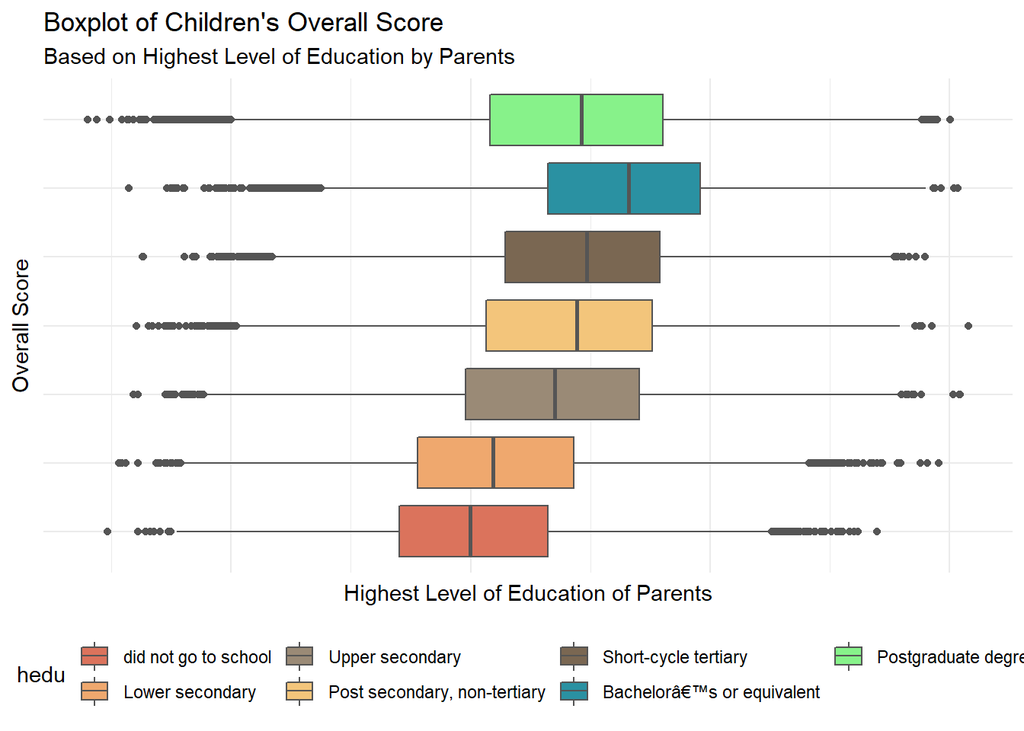

> تسلط به زبان آزمون

در این قسمت دانش آموزان را بر حسب اینکه چه مقدار در خانه به زبان آزمون صحبت میکنند دسته بندی کرده ایم.

```
##                         Df    Sum Sq  Mean Sq F value Pr(>F)
## as.factor(language)      3 1.908e+08 63600860    6420 <2e-16 ***
## Residuals           281663 2.790e+09     9906
## ---
## Signif. codes:  0 '***' 0.001 '**' 0.01 '*' 0.05 '.' 0.1 ' ' 1
```

```
##
##  Pearson's Chi-squared test
##
## data:  matrix(as.numeric(language15.stat8th.summary$freq), nrow = 4,     byrow = T)
## X-squared = 14370, df = 9, p-value < 2.2e-16
```

[interactive chart not shown]

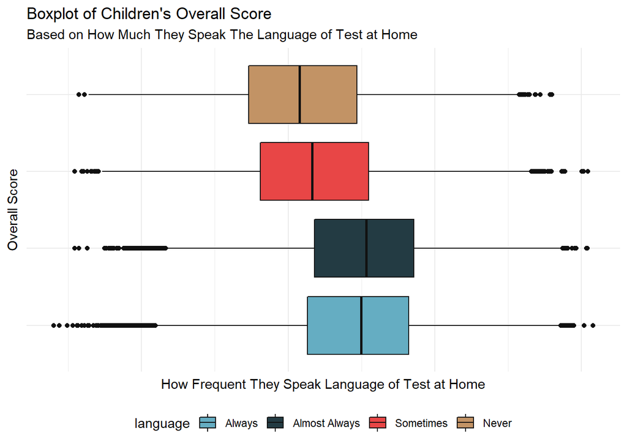

#### School Composition and Resources

بررسی تاثیر وضعیت اقتصادی دانش آموزان بر عملکرد آن ها در آزمون اساس پاسخ مدیر مدارس. میبینیم که عملکرد مدارسی که بیشتر دانش آموزان آن از خانواده های مرفه هستند بهتر از بقیه مدارس می باشد.

```
##                            Df   Sum Sq Mean Sq F value Pr(>F)
## as.factor(economicState)    2  7462838 3731419   692.4 <2e-16 ***
## Residuals                7397 39863190    5389
## ---
## Signif. codes:  0 '***' 0.001 '**' 0.01 '*' 0.05 '.' 0.1 ' ' 1
```

[interactive chart not shown]

بررسی تاثیر کمبود امکانات بر روی تدریس. عملکرد مدارسی که کمبودی ندارند به طور واضح بهتر است.

```
##                        Df   Sum Sq Mean Sq F value Pr(>F)
## as.factor(resources)    2  4276330 2138165   357.3 <2e-16 ***
## Residuals            7334 43891746    5985
## ---
## Signif. codes:  0 '***' 0.001 '**' 0.01 '*' 0.05 '.' 0.1 ' ' 1
```

[interactive chart not shown]

#### School Climate

نظر معلمان نسبت به وضعیت و امکانات مدرسه. عملکرد در مدارسی که مشکل کمتری دارند بهتر از بقیه می باشد.  
اطلاعات بر حسب جواب معلمان می باشد.

```
##                         Df   Sum Sq Mean Sq F value Pr(>F)
## as.factor(condition)     2  3322834 1661417   263.4 <2e-16 ***
## Residuals            12431 78408787    6308
## ---
## Signif. codes:  0 '***' 0.001 '**' 0.01 '*' 0.05 '.' 0.1 ' ' 1
```

[interactive chart not shown]

تاکید مدرسه بر موفقیت درسی بر روی عملکرد دانش آموزان اثر دارد.

```
##                       Df   Sum Sq Mean Sq F value Pr(>F)
## as.factor(emphasis)    3  8054804 2684935   487.2 <2e-16 ***
## Residuals           7948 43796516    5510
## ---
## Signif. codes:  0 '***' 0.001 '**' 0.01 '*' 0.05 '.' 0.1 ' ' 1
```

[interactive chart not shown]

بر حسب جواب دانش آموزان به این مورد پرداخته ایم که آیا حس تعلق و راحتی در مدرسه تاثیری بر عملکرد آن ها دارد یا خیر.

```
##                          Df    Sum Sq Mean Sq F value Pr(>F)
## as.factor(belonging)      2 1.423e+06  711282   110.7 <2e-16 ***
## Residuals            269807 1.734e+09    6428
## ---
## Signif. codes:  0 '***' 0.001 '**' 0.01 '*' 0.05 '.' 0.1 ' ' 1
```

[interactive chart not shown]

#### School Discipline and Safety

در این قسمت امنیت و نظم مدرسه را با توجه به سوالات پرسیده شده از دانش آموزان،معلمان و مدیر مدرسه ارزیابی کردیم و میانگین هر دسته را به دست آوردیم.

> از دیدگاه مدیر مدرسه

در این قسمت پاسخ مدیران به سوالاتی در رابطه با مشکلاتی از قبیل:

- دیر آمدن به مدرسه
- غیبت کردن
- تقلب
- دزدی
- و …

را بررسی کردیم و مدارس را مطابقا دسته بندی کردیم.

```
##                         Df   Sum Sq Mean Sq F value Pr(>F)
## as.factor(safety.cat)    3  5982289 1994096   350.6 <2e-16 ***
## Residuals             7846 44630777    5688
## ---
## Signif. codes:  0 '***' 0.001 '**' 0.01 '*' 0.05 '.' 0.1 ' ' 1
```

[interactive chart not shown]

> از دیدگاه معلمان مدرسه

در این قسمت، مانند قسمت قبل پاسخ معلمان را به همان سوالات ارزیابی کردیم و دانش آموزان هر معلم را دسته بندی کردیم.

```
##                          Df    Sum Sq Mean Sq F value Pr(>F)
## as.factor(safety.cat)     3   6796310 2265437   368.6 <2e-16 ***
## Residuals             30286 186146246    6146
## ---
## Signif. codes:  0 '***' 0.001 '**' 0.01 '*' 0.05 '.' 0.1 ' ' 1
```

[interactive chart not shown]

> از دیدگاه دانش آموزان

در این قسمت میزان آزار و اذیتی که دانش آموزان از جانب دیگر دانش آموزان میبینند را بررسی کردیم

```
##                             Df    Sum Sq  Mean Sq F value Pr(>F)
## as.factor(bullying.cat)      3 1.262e+08 42051715    4333 <2e-16 ***
## Residuals               261837 2.541e+09     9704
## ---
## Signif. codes:  0 '***' 0.001 '**' 0.01 '*' 0.05 '.' 0.1 ' ' 1
```

```
##
##  Pearson's Chi-squared test
##
## data:  matrix(as.numeric(stud15.stat8th.summary$freq), nrow = 4, ncol = 4,     byrow = T)
## X-squared = 7414.8, df = 9, p-value < 2.2e-16
```

[interactive chart not shown]

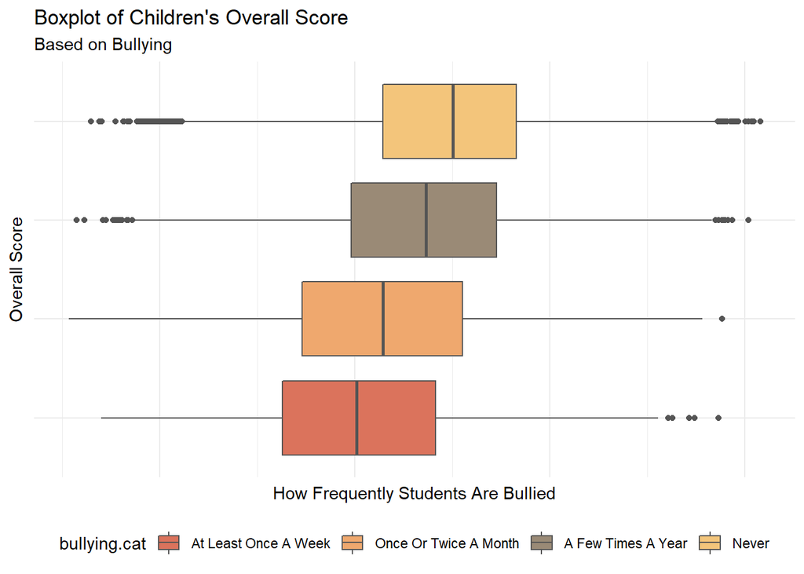

#### Teachers’ and Principals’ Preparation

> تاثیر میزان تجربه مدیر مدرسه بر عملکرد مدرسه در آزمون.

```
##                         Df   Sum Sq Mean Sq F value   Pr(>F)
## as.factor(experience)    3   119934   39978    6.16 0.000354 ***
## Residuals             7895 51241682    6490
## ---
## Signif. codes:  0 '***' 0.001 '**' 0.01 '*' 0.05 '.' 0.1 ' ' 1
```

[interactive chart not shown]

> تاثیر میزان تحصیلات مدیر بر روی عملکرد در آزمون.

```
##                        Df   Sum Sq Mean Sq F value Pr(>F)
## as.factor(education)    3  5336765 1778922   302.8 <2e-16 ***
## Residuals            8035 47211358    5876
## ---
## Signif. codes:  0 '***' 0.001 '**' 0.01 '*' 0.05 '.' 0.1 ' ' 1
```

[interactive chart not shown]

> عملکرد دانش آموزان بر اساس میزان تجربه معلمان.

```
##                          Df   Sum Sq Mean Sq F value   Pr(>F)
## as.factor(experience)     3   158219   52740   8.056 2.33e-05 ***
## Residuals             12500 81836331    6547
## ---
## Signif. codes:  0 '***' 0.001 '**' 0.01 '*' 0.05 '.' 0.1 ' ' 1
```

[interactive chart not shown]

> بررسی میزان تحصیلات معلمان بر عملکرد دانش آموزان آن ها.

```
##                         Df   Sum Sq Mean Sq F value Pr(>F)
## as.factor(education)     3  2347540  782513   124.1 <2e-16 ***
## Residuals            12008 75710782    6305
## ---
## Signif. codes:  0 '***' 0.001 '**' 0.01 '*' 0.05 '.' 0.1 ' ' 1
```

[interactive chart not shown]

#### Classroom Instruction

> بررسی تاثیر میزان تکلیف بر عملکرد دانش آموزان سال هشتم.

```
##                         Df    Sum Sq  Mean Sq F value Pr(>F)
## as.factor(homework)      4 4.525e+07 11311504    1734 <2e-16 ***
## Residuals           217749 1.420e+09     6522
## ---
## Signif. codes:  0 '***' 0.001 '**' 0.01 '*' 0.05 '.' 0.1 ' ' 1
```

[interactive chart not shown]

> محدودیت معلمان در هنگام تدریس بر حسب نیاز دانش آموزان نیز بر عملکرد آن ها تاثیر دارد.

```
##                     Df   Sum Sq Mean Sq F value Pr(>F)
## as.factor(limit)     2  9664433 4832216   842.4 <2e-16 ***
## Residuals        12014 68913994    5736
## ---
## Signif. codes:  0 '***' 0.001 '**' 0.01 '*' 0.05 '.' 0.1 ' ' 1
```

[interactive chart not shown]

> عملکرد دانش آموزان بر حسب تعداد غیبت آن ها.

```
##                       Df    Sum Sq  Mean Sq F value Pr(>F)
## as.factor(absent)      3 9.013e+07 30043749    4776 <2e-16 ***
## Residuals         269852 1.697e+09     6290
## ---
## Signif. codes:  0 '***' 0.001 '**' 0.01 '*' 0.05 '.' 0.1 ' ' 1
```

[interactive chart not shown]

#### Student Engagement and Attitudes

> مشارکت در کلاس

در این قسمت پاسخ دانش آموزان به سوالاتی در رابطه با کلاس ریاضی شان مانند :

- علاقه به مباحث کلاس
- فن بیان معلم
- تنوع در نحوه ی تدریس
- و …

را بررسی کردیم و بر حسب میزان مشارکت، آن ها را دسته بندی کردیم

```
##                            Df    Sum Sq Mean Sq F value Pr(>F)
## as.factor(lessons.cat)      3 1.383e+07 4610553   454.1 <2e-16 ***
## Residuals              266541 2.706e+09   10152
## ---
## Signif. codes:  0 '***' 0.001 '**' 0.01 '*' 0.05 '.' 0.1 ' ' 1
```

```
##
##  Pearson's Chi-squared test
##
## data:  matrix(as.numeric(mstudles15.stat8th.summary$freq), nrow = 4,     ncol = 4, byrow = T)
## X-squared = 1392, df = 9, p-value < 2.2e-16
```

[interactive chart not shown]

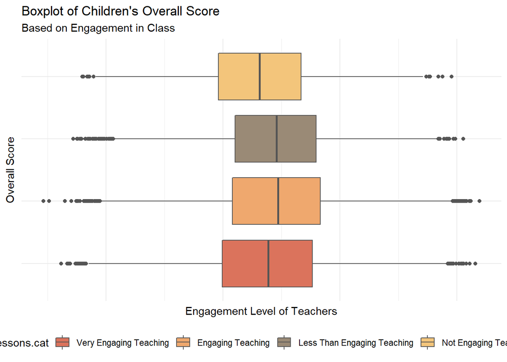

> علاقه به ریاضی

در این قسمت پاسخ دانش آموزان به سوالاتی در رابطه با علاقه به ریاضیات و یادگیری را بررسی کردیم.

```
##                             Df    Sum Sq  Mean Sq F value Pr(>F)
## as.factor(learning.cat)      3 4.171e+07 13902369    1380 <2e-16 ***
## Residuals               262654 2.646e+09    10073
## ---
## Signif. codes:  0 '***' 0.001 '**' 0.01 '*' 0.05 '.' 0.1 ' ' 1
```

```
##
##  Pearson's Chi-squared test
##
## data:  matrix(as.numeric(mstudlearn15.stat8th.summary$freq), nrow = 4,     ncol = 4, byrow = T)
## X-squared = 4055, df = 9, p-value < 2.2e-16
```

[interactive chart not shown]

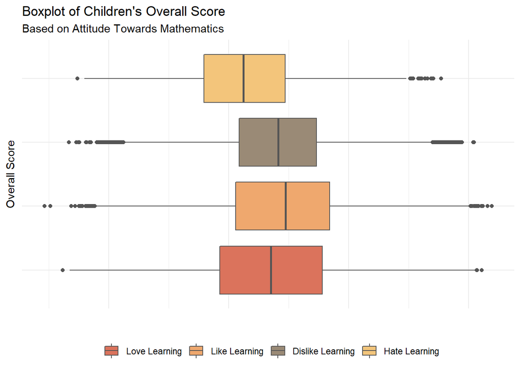

> اعتماد به نفس

در این قسمت دانش آموزان را بر حسب اعتماد به نفسشان در رابطه با ریاضی دسته بندی کردیم.

```
##                               Df    Sum Sq   Mean Sq F value Pr(>F)
## as.factor(confidence.cat)      2 2.484e+08 124195466   13376 <2e-16 ***
## Residuals                 261968 2.432e+09      9285
## ---
## Signif. codes:  0 '***' 0.001 '**' 0.01 '*' 0.05 '.' 0.1 ' ' 1
```

```
##
##  Pearson's Chi-squared test
##
## data:  matrix(as.numeric(mstudconf15.stat8th.summary$freq), ncol = 3,     byrow = T)
## X-squared = 18290, df = 6, p-value < 2.2e-16
```

[interactive chart not shown]

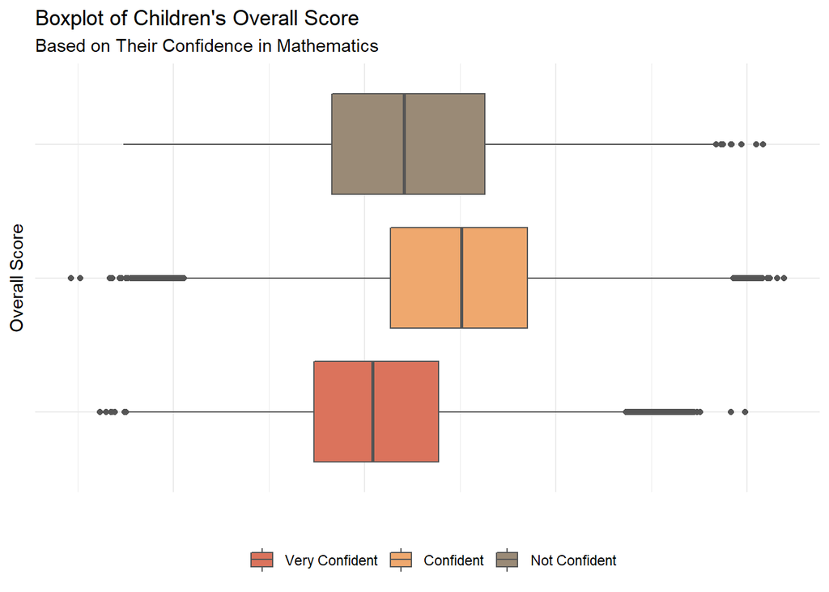

> اهمیت به ریاضی

در این قسمت، دانش آموزان را بر حسب میزان اهمیتی که به ریاضی میدهند و میزان ارزشی که ریاضیات برای شغل آینده، دانشگاه و … دارد دسته بندی کردیم.

```
##                          Df    Sum Sq Mean Sq F value Pr(>F)
## as.factor(value.cat)      2 1.433e+07 7164695   702.7 <2e-16 ***
## Residuals            269557 2.748e+09   10196
## ---
## Signif. codes:  0 '***' 0.001 '**' 0.01 '*' 0.05 '.' 0.1 ' ' 1
```

```
##
##  Pearson's Chi-squared test
##
## data:  matrix(as.numeric(mstudval15.stat8th.summary$freq), ncol = 3,     byrow = T)
## X-squared = 1215.4, df = 6, p-value < 2.2e-16
```

[interactive chart not shown]

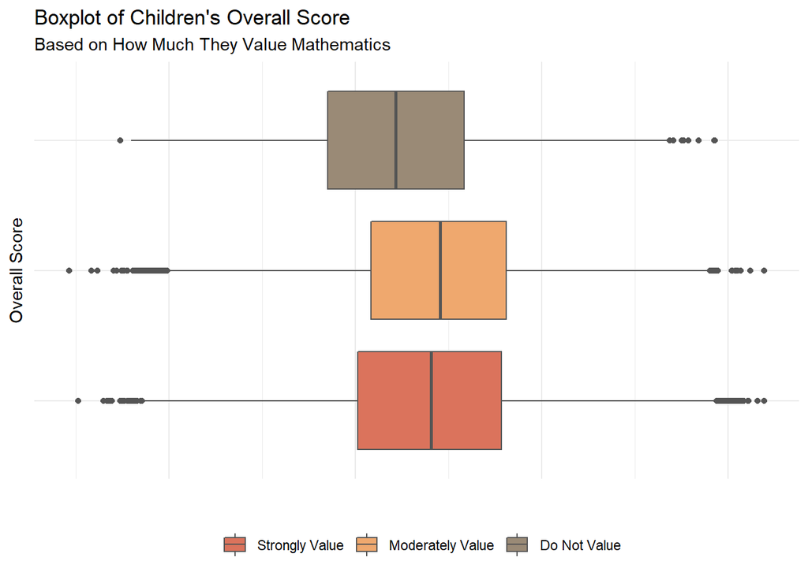